# Analisis univariable: analisis descriptivo y temporal y preprocesado

# Nota: Este codigo cubre los resultados de los apartado del trabajo 2.3. Analisis descriptivo y pre-procesado de datos

```r
#Cargamos los datos
electricity_prices<-read.csv("~/Documents/UOC/TF/electricity_prices.csv", header=TRUE) #Sustituir por el directorio donde se encuentra el fichero csv con los datos
```

```r
#Eliminamos las columnas inecesarias para este estudio (demanda residual - demres) creando un nuevo data frame
ep<- electricity_prices[,-21]
```

```r
#Resumen datos
summary(ep)
```

```
         Date            Hour        DayofWeek         Month         WeekofMonth         MD              MI1              MI2
 2014-01-01:   24   Min.   : 1.0   Min.   :1.000   Min.   : 1.000   Min.   :1.00   Min.   :  0.00   Min.   :  0.00   Min.   :  0.00
 2014-01-02:   24   1st Qu.: 7.0   1st Qu.:2.000   1st Qu.: 3.000   1st Qu.:2.00   1st Qu.: 37.50   1st Qu.: 37.00   1st Qu.: 37.03
 2014-01-03:   24   Median :13.0   Median :4.000   Median : 6.000   Median :3.00   Median : 46.52   Median : 46.00   Median : 46.00
 2014-01-04:   24   Mean   :12.5   Mean   :4.001   Mean   : 6.222   Mean   :2.83   Mean   : 45.29   Mean   : 44.92   Mean   : 44.91
 2014-01-05:   24   3rd Qu.:18.5   3rd Qu.:6.000   3rd Qu.: 9.000   3rd Qu.:4.00   3rd Qu.: 55.10   3rd Qu.: 55.00   3rd Qu.: 54.89
 2014-01-06:   24   Max.   :24.0   Max.   :7.000   Max.   :12.000   Max.   :5.00   Max.   :113.92   Max.   :102.49   Max.   :103.61
 (Other)   :32711
      MI3              MI4              MI5              MI6              MI7             dem             eol             nuc
 Min.   :  0.00   Min.   :  0.00   Min.   :  0.00   Min.   :  0.00   Min.   : 0.00   Min.   :17534   Min.   :  178   Min.   :   0
 1st Qu.: 38.40   1st Qu.: 40.00   1st Qu.: 40.00   1st Qu.: 39.99   1st Qu.:40.00   1st Qu.:24477   1st Qu.: 3024   1st Qu.:6106
 Median : 47.00   Median : 48.67   Median : 48.59   Median : 48.92   Median :49.51   Median :28641   Median : 4875   Median :7117
 Mean   : 46.09   Mean   : 47.65   Mean   : 47.81   Mean   : 47.78   Mean   :48.27   Mean   :28380   Mean   : 5517   Mean   :6481
 3rd Qu.: 56.10   3rd Qu.: 57.87   3rd Qu.: 58.00   3rd Qu.: 58.28   3rd Qu.:58.79   3rd Qu.:31866   3rd Qu.: 7462   3rd Qu.:7117
 Max.   :104.61   Max.   :105.71   Max.   :102.35   Max.   :102.00   Max.   :99.80   Max.   :41514   Max.   :17430   Max.   :7117
 NA's   :5475     NA's   :9582     NA's   :15058    NA's   :20534    NA's   :28748
      tot             hid             cco             sol
 Min.   : 7117   Min.   :10334   Min.   :14176   Min.   :    0.0
 1st Qu.:52425   1st Qu.:12658   1st Qu.:21983   1st Qu.:   85.5
 Median :54310   Median :13345   Median :22987   Median :  599.7
 Mean   :54187   Mean   :13269   Mean   :22664   Mean   : 1482.3
 3rd Qu.:55998   3rd Qu.:14005   3rd Qu.:23433   3rd Qu.: 2714.8
 Max.   :60855   Max.   :56684   Max.   :24560   Max.   :22604.1
                 NA's   :24                      NA's   :1
```

Dado que los mercados diarios 3, 4, 5, 6 y 7 no comercializan electricidad para todas las franjas horarias, existen observaciones sin datos (NAs) Por otra parte, observamos que las variabes sol y hid tienen NA’s, en este caso deberemos estudiar si se trata de un error de datos.

```r
#Creamos vectores con las variables a estudiar
price_MD<-electricity_prices$MD
price_MI1<-electricity_prices$MI1
price_MI2<-electricity_prices$MI2
price_MI3<-electricity_prices$MI3
price_MI4<-electricity_prices$MI4
price_MI5<-electricity_prices$MI5
price_MI6<-electricity_prices$MI6
price_MI7<-electricity_prices$MI7
hour<-electricity_prices$Hour
```

# 1. Analisis precios

```r
#Analisis univariable
#Distribucion estadistica precios
#Creamos un data frame con los precios de los diferentes mercados
prices<-data.frame(electricity_prices$MD, electricity_prices$MI1, electricity_prices$MI2, electricity_prices$MI3, electricity_prices$MI4, electricity_prices$MI5, electricity_prices$MI6, electricity_prices$MI7)
names(prices)<-c("MD","MI1", "MI2", "MI3", "MI4", "MI5", "MI6", "MI7")
summary(prices)
```

```
       MD              MI1              MI2              MI3              MI4              MI5              MI6              MI7
 Min.   :  0.00   Min.   :  0.00   Min.   :  0.00   Min.   :  0.00   Min.   :  0.00   Min.   :  0.00   Min.   :  0.00   Min.   : 0.00
 1st Qu.: 37.50   1st Qu.: 37.00   1st Qu.: 37.03   1st Qu.: 38.40   1st Qu.: 40.00   1st Qu.: 40.00   1st Qu.: 39.99   1st Qu.:40.00
 Median : 46.52   Median : 46.00   Median : 46.00   Median : 47.00   Median : 48.67   Median : 48.59   Median : 48.92   Median :49.51
 Mean   : 45.29   Mean   : 44.92   Mean   : 44.91   Mean   : 46.09   Mean   : 47.65   Mean   : 47.81   Mean   : 47.78   Mean   :48.27
 3rd Qu.: 55.10   3rd Qu.: 55.00   3rd Qu.: 54.89   3rd Qu.: 56.10   3rd Qu.: 57.87   3rd Qu.: 58.00   3rd Qu.: 58.28   3rd Qu.:58.79
 Max.   :113.92   Max.   :102.49   Max.   :103.61   Max.   :104.61   Max.   :105.71   Max.   :102.35   Max.   :102.00   Max.   :99.80
                                                    NA's   :5475     NA's   :9582     NA's   :15058    NA's   :20534    NA's   :28748
```

Observamos que el promedio de los precios en los diferentes mercados oscila aproximadamente entre los 44 - 48 euros. La variable con la media de precio mas elevada es el precio en el mercado interdiario 7. No obstante, la variable con precio maximo mas elevado es el precio del mercado diario. Finalmente, observamos que todas las observaciones tienen un minimo de 0.00 euros

# 1.1.Analisis univariable de la variable precio MD

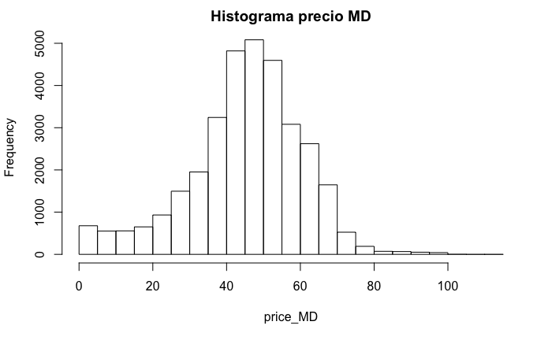

```r
#Creamos un histograma para observar la distribucion
hist(price_MD, main="Histograma precio MD")
```

La distribucion presenta una ligera desviacion hacia la izquierda (skewed to the left). Esto significa que la frequencia de observaciones en la cola de la izquierda (precios bajos) es mayor que en la derecha (precios altos). Por lo tanto, parece que la variable no cumple con las condiciones de normalidad.

```r
#Miramos la normalidad
library(e1071)
skewness(price_MD)
```

```
[1] -0.5165228
```

```r
kurtosis(price_MD)
```

```
[1] 0.6864137
```

La variable no presenta una distribucion normal, sino una distribucion asimetrica con mas frecuencia en precios bajos que altos, como demuestra el grado de skweness

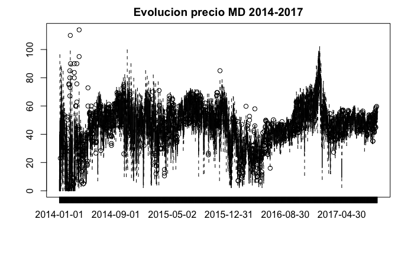

```r
#Observamos la evolucion temporal del precio en el mercado diario
plot(electricity_prices$Date, electricity_prices$MD, main="Evolucion precio MD 2014-2017")
```

Se puede observar cierta ciclicidad en la evolucion temporal, con algunos picos, los mas destacables al inicio de 2014 y al inicio de 2017. Asi mismo, se observa un declive en los precios a inicios de 2016.

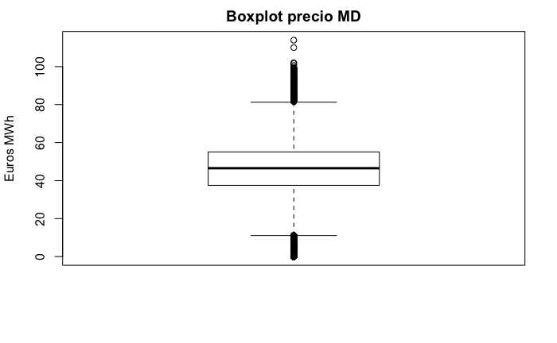

```r
#Creamos un boxplot
boxplot(price_MD, main="Boxplot precio MD", ylab="Euros MWh")
```

La mayoria de observaciones se situan entre 37.50 euros y 55.10 euros, con una media de 45.29 euros por MWh

```r
#Estudiamos los outliers con valores mas elevados
prices_1<-data.frame(electricity_prices$Date, electricity_prices$Hour, electricity_prices$DayofWeek,electricity_prices$MD, electricity_prices$MI1, electricity_prices$MI2, electricity_prices$MI3, electricity_prices$MI4, electricity_prices$MI5, electricity_prices$MI6, electricity_prices$MI7, electricity_prices$dem)
names(prices_1)<-c("Date", "Hour", "DayofWeek", "MD","MI1", "MI2", "MI3", "MI4", "MI5", "MI6", "MI7", "dem")
prices_1[prices_1$MD>99,] #Seleccionamos las filas donde el precio del MD es superior a 99
```

|  | Date | Hour | DayofWeek | MD | MI1 | MI2 | MI3 | MI4 | MI5 | MI6 | MI7 | dem |
| --- | --- | --- | --- | --- | --- | --- | --- | --- | --- | --- | --- | --- |
| 1150 | 2014-02-17 | 22 | 1 | 110.00 | 80.01 | 77.00 | 70.00 | 55.00 | 57.96 | 42.25 | 37.56 | 36182 |
| 2060 | 2014-03-27 | 20 | 4 | 113.92 | 95.92 | 85.00 | 83.00 | 83.00 | 65.70 | 52.86 | NA | 32850 |
| 7029 | 2014-10-20 | 21 | 1 | 99.77 | 92.77 | 90.20 | 83.07 | 87.00 | 84.77 | 79.82 | NA | 32787 |
| 26876 | 2017-01-24 | 21 | 2 | 99.10 | 99.10 | 98.99 | 99.20 | 99.15 | 99.10 | 102.00 | NA | 39304 |
| 26898 | 2017-01-25 | 19 | 3 | 99.18 | 99.18 | 98.78 | 99.19 | 97.20 | 97.18 | 97.68 | NA | 37763 |
| 26899 | 2017-01-25 | 20 | 3 | 101.70 | 100.70 | 99.70 | 101.70 | 99.72 | 99.70 | 100.20 | NA | 39114 |
| 26900 | 2017-01-25 | 21 | 3 | 101.99 | 100.97 | 99.61 | 101.65 | 101.79 | 99.99 | 99.99 | NA | 39324 |
| 26901 | 2017-01-25 | 22 | 3 | 100.67 | 99.67 | 98.72 | 100.67 | 100.67 | 99.00 | 98.67 | 89.90 | 38312 |
| 26902 | 2017-01-25 | 23 | 3 | 99.18 | 101.35 | 101.18 | 101.75 | 100.18 | 99.18 | 100.00 | 89.90 | 35470 |

```r
#Estudiamos los outliers con valores mas bajos
price_MD1<-data.frame(electricity_prices$Date, electricity_prices$Hour, electricity_prices$DayofWeek,electricity_prices$MD)
names(price_MD1)<-c("Date", "Hour", "DayofWeek", "MD")
prices_MD0<-data.frame(price_MD1[price_MD1$MD==0,])
table(prices_MD0$Hour)
```

```
 1  2  3  4  5  6  7  8  9 10 11 12 13 14 15 16 17 18 19
 2 13 21 24 25 23 19  7  7  6  3  2  2  2  3  5  6  6  1
```

```r
#Estudiamos los outliers con valores mas bajos
summary(prices_MD0$Date)
```

```
2014-02-08 2014-01-04 2014-02-09 2014-03-02 2014-01-05 2014-01-01 2014-02-10 2014-03-03 2014-01-02 2014-02-05 2014-02-07 2014-02-11 2014-02-13
        17         15         14         11          9          8          8          7          6          6          6          6          6
2014-02-14 2014-03-04 2014-01-27 2014-01-28 2014-01-03 2014-01-06 2014-01-14 2014-01-29 2014-02-06 2014-02-17 2014-03-09 2014-02-23 2014-03-05
         6          6          5          5          4          4          4          4          4          4          4          3          3
2014-02-21 2014-01-07 2014-01-08 2014-01-09 2014-01-10 2014-01-11 2014-01-12 2014-01-13 2014-01-15 2014-01-16 2014-01-17 2014-01-18 2014-01-19
         2          0          0          0          0          0          0          0          0          0          0          0          0
2014-01-20 2014-01-21 2014-01-22 2014-01-23 2014-01-24 2014-01-25 2014-01-26 2014-01-30 2014-01-31 2014-02-01 2014-02-02 2014-02-03 2014-02-04
         0          0          0          0          0          0          0          0          0          0          0          0          0
2014-02-12 2014-02-15 2014-02-16 2014-02-18 2014-02-19 2014-02-20 2014-02-22 2014-02-24 2014-02-25 2014-02-26 2014-02-27 2014-02-28 2014-03-01
         0          0          0          0          0          0          0          0          0          0          0          0          0
2014-03-06 2014-03-07 2014-03-08 2014-03-10 2014-03-11 2014-03-12 2014-03-13 2014-03-14 2014-03-15 2014-03-16 2014-03-17 2014-03-18 2014-03-19
         0          0          0          0          0          0          0          0          0          0          0          0          0
2014-03-20 2014-03-21 2014-03-22 2014-03-23 2014-03-24 2014-03-25 2014-03-26 2014-03-27 2014-03-28 2014-03-29 2014-03-30 2014-03-31 2014-04-01
         0          0          0          0          0          0          0          0          0          0          0          0          0
2014-04-02 2014-04-03 2014-04-04 2014-04-05 2014-04-06 2014-04-07 2014-04-08 2014-04-09    (Other)
         0          0          0          0          0          0          0          0          0
```

Observamos que la mayoria de casos se dan de madrugada (entre las 2 y las 7 de la ma??ana) y corresponden a los meses de enero, febrero y marzo de 2014.

# 1.2. Analisis de la variable precio MI_1

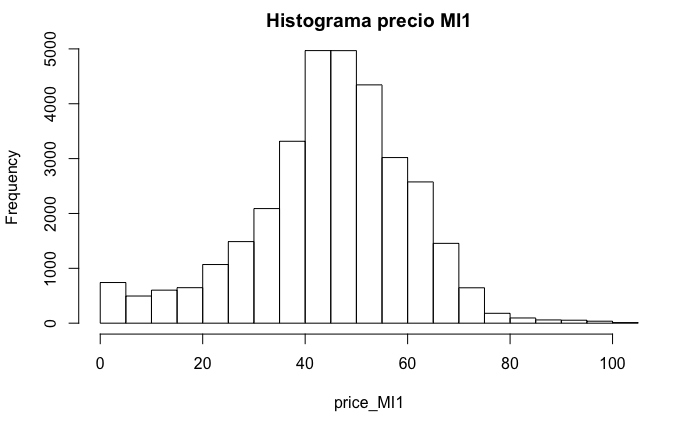

```r
#Creamos un histograma para observar la distribucion
hist(price_MI1, main="Histograma precio MI1")
```

```r
#Miramos la normalidad
library(e1071)
skewness(price_MI1)
```

```
[1] -0.4858547
```

```r
kurtosis(price_MI1)
```

```
[1] 0.6627879
```

De nuevo, la distribucion presenta una asimetria con mas frecuancia en precios bajos que altos. La distribucion es muy parecida a la del mercado diario.

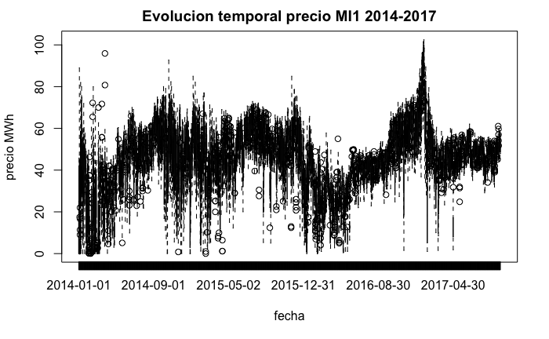

```r
#Analisis temporal evolucion precios del mercado intradiario 1
plot(electricity_prices$Date, price_MI1, type="l", xlab="fecha", ylab="precio MWh", main="Evolucion temporal precio MI1 2014-2017")
```

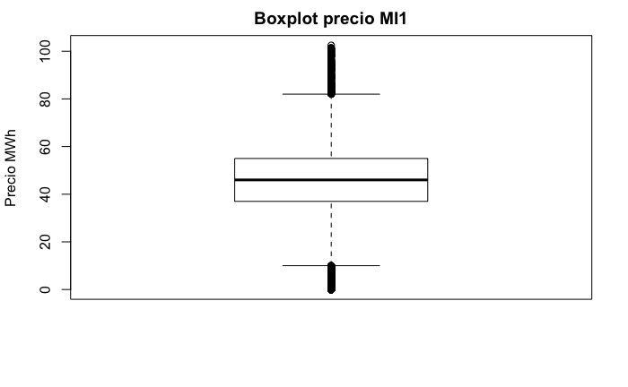

```r
#Creamos un boxplot
boxplot(price_MI1, main="Boxplot precio MI1", ylab = "Precio MWh")
```

```r
#Estudiamos los outliers mas elevados
prices_1[prices_1$MI1>100,]
```

|  | Date | Hour | DayofWeek | MD | MI1 | MI2 | MI3 | MI4 | MI5 | MI6 | MI7 | dem |
| --- | --- | --- | --- | --- | --- | --- | --- | --- | --- | --- | --- | --- |
| 26841 | 2017-01-23 | 10 | 1 | 95.10 | 100.81 | 101.50 | 98.10 | 98.50 | NA | NA | NA | 37212 |
| 26842 | 2017-01-23 | 11 | 1 | 95.10 | 100.90 | 101.50 | 98.69 | 99.10 | NA | NA | NA | 38033 |
| 26851 | 2017-01-23 | 20 | 1 | 97.00 | 100.50 | 101.00 | 98.69 | 98.69 | 98.72 | 102.00 | NA | 38955 |
| 26852 | 2017-01-23 | 21 | 1 | 97.67 | 101.50 | 102.00 | 99.50 | 99.67 | 99.56 | 102.00 | NA | 39321 |
| 26888 | 2017-01-25 | 9 | 3 | 98.01 | 100.31 | 102.81 | 103.81 | 104.85 | NA | NA | NA | 36607 |
| 26889 | 2017-01-25 | 10 | 3 | 98.61 | 101.18 | 103.61 | 104.61 | 105.65 | NA | NA | NA | 37551 |
| 26890 | 2017-01-25 | 11 | 3 | 98.61 | 102.49 | 103.61 | 104.61 | 105.71 | NA | NA | NA | 38234 |
| 26899 | 2017-01-25 | 20 | 3 | 101.70 | 100.70 | 99.70 | 101.70 | 99.72 | 99.70 | 100.20 | NA | 39114 |
| 26900 | 2017-01-25 | 21 | 3 | 101.99 | 100.97 | 99.61 | 101.65 | 101.79 | 99.99 | 99.99 | NA | 39324 |
| 26902 | 2017-01-25 | 23 | 3 | 99.18 | 101.35 | 101.18 | 101.75 | 100.18 | 99.18 | 100.00 | 89.9 | 35470 |

Estos outliers corresponden a fechas de enero 2017

# 1.3. Analisis de la variable precio MI_2

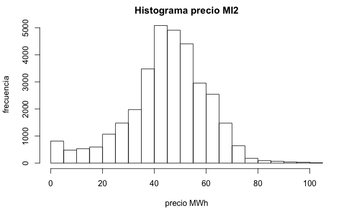

```r
#Creamos un histograma para observar la distribucion
hist_MI2<-hist(price_MI2, xlab="precio MWh", ylab="frecuencia",main="Histograma precio MI2")
```

```r
#Miramos la normalidad
library(e1071)
skewness(price_MI2)
```

```
[1] -0.5167019
```

```r
kurtosis(price_MI2)
```

```
[1] 0.7384189
```

La distribucion sigue presentando una asimetria con mas frecuencia de observaciones en los precios bajos que altos.

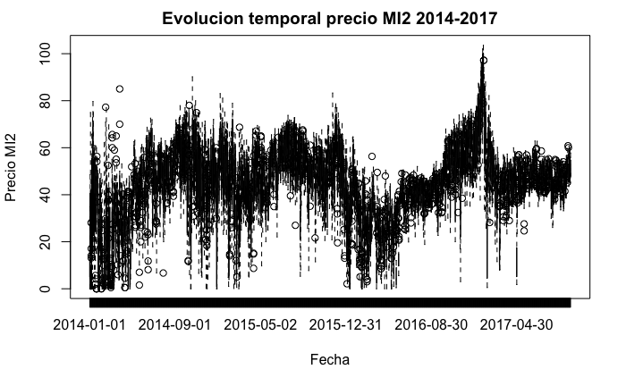

```r
#Analisis temporal evolucion precios
plot(electricity_prices$Date, electricity_prices$MI2, type="l", xlab="Fecha", ylab="Precio MI2", main="Evolucion temporal precio MI2 2014-2017")
```

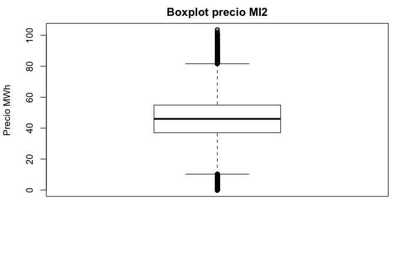

```r
#Creamos un boxplot
boxplot(price_MI2, main="Boxplot precio MI2", ylab= "Precio MWh")
```

Las variables descriptivas son similares a las del mercado interdiario 1. La evolucion de la variable en el tiempo presenta el mismo tipo de tendencias que en los analisis anteriores.

```r
#Estudiamos los outliers mas extremos con precios elevados
prices_1[prices_1$MI2>100,]
```

|  | Date | Hour | DayofWeek | MD | MI1 | MI2 | MI3 | MI4 | MI5 | MI6 | MI7 | dem |
| --- | --- | --- | --- | --- | --- | --- | --- | --- | --- | --- | --- | --- |
| 26841 | 2017-01-23 | 10 | 1 | 95.10 | 100.81 | 101.50 | 98.10 | 98.50 | NA | NA | NA | 37212 |
| 26842 | 2017-01-23 | 11 | 1 | 95.10 | 100.90 | 101.50 | 98.69 | 99.10 | NA | NA | NA | 38033 |
| 26843 | 2017-01-23 | 12 | 1 | 93.21 | 100.00 | 100.50 | 98.19 | 98.30 | 98.69 | NA | NA | 38061 |
| 26851 | 2017-01-23 | 20 | 1 | 97.00 | 100.50 | 101.00 | 98.69 | 98.69 | 98.72 | 102 | NA | 38955 |
| 26852 | 2017-01-23 | 21 | 1 | 97.67 | 101.50 | 102.00 | 99.50 | 99.67 | 99.56 | 102 | NA | 39321 |
| 26888 | 2017-01-25 | 9 | 3 | 98.01 | 100.31 | 102.81 | 103.81 | 104.85 | NA | NA | NA | 36607 |
| 26889 | 2017-01-25 | 10 | 3 | 98.61 | 101.18 | 103.61 | 104.61 | 105.65 | NA | NA | NA | 37551 |
| 26890 | 2017-01-25 | 11 | 3 | 98.61 | 102.49 | 103.61 | 104.61 | 105.71 | NA | NA | NA | 38234 |
| 26891 | 2017-01-25 | 12 | 3 | 97.35 | 99.92 | 100.27 | 101.95 | 102.99 | 102.35 | NA | NA | 38190 |
| 26892 | 2017-01-25 | 13 | 3 | 96.50 | 99.77 | 100.17 | 101.17 | 101.30 | 101.49 | NA | NA | 37856 |

[output cut: 2 more lines]

Los valores corresponden a obervaciones del 23 y 25 de enero de 2017 (como en el MI1)

# 1.3. Analisis univariable price_MI3

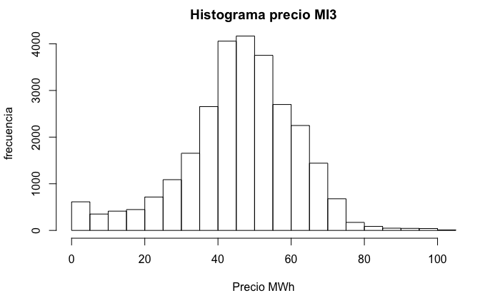

```r
#Creamos un histograma para observar la distribucion
hist_MI3<-hist(price_MI3, xlab="Precio MWh", ylab="frecuencia", main="Histograma precio MI3")
```

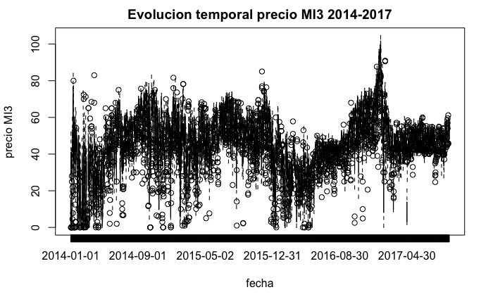

```r
#Analisis temporal evolucion precios
plot(electricity_prices$Date, price_MI3, type="l", xlab="fecha", ylab="precio MI3", main="Evolucion temporal precio MI3 2014-2017")
```

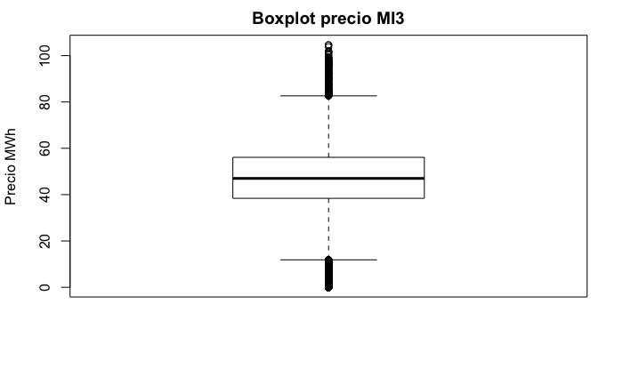

```r
#Creamos un boxplot
boxplot(price_MI3, main="Boxplot precio MI3", ylab= "Precio MWh")
```

```r
#Estudiamos los outliers mas extremos con precios elevados
outl_MI3<-prices_1[prices_1$MI3>90,]
out_MI3<-na.omit(outl_MI3)
out_MI3
```

|  | Date | Hour | DayofWeek | MD | MI1 | MI2 | MI3 | MI4 | MI5 | MI6 | MI7 | dem |
| --- | --- | --- | --- | --- | --- | --- | --- | --- | --- | --- | --- | --- |
| 26733 | 2017-01-18 | 22 | 3 | 92.01 | 90.29 | 90.29 | 91.41 | 89.01 | 89.79 | 93.01 | 97.00 | 40358 |
| 26734 | 2017-01-18 | 23 | 3 | 89.22 | 89.25 | 89.25 | 90.72 | 89.22 | 90.01 | 93.51 | 95.00 | 37145 |
| 26757 | 2017-01-19 | 22 | 4 | 89.19 | 91.17 | 93.00 | 91.50 | 92.00 | 92.00 | 92.00 | 99.80 | 40258 |
| 26758 | 2017-01-19 | 23 | 4 | 85.46 | 88.46 | 90.10 | 92.46 | 89.50 | 92.77 | 90.46 | 98.19 | 37322 |
| 26781 | 2017-01-20 | 22 | 5 | 95.03 | 94.59 | 92.63 | 92.10 | 92.10 | 93.13 | 96.00 | 99.03 | 38861 |
| 26782 | 2017-01-20 | 23 | 5 | 94.70 | 95.86 | 94.70 | 93.67 | 94.78 | 94.70 | 95.80 | 99.70 | 36265 |
| 26783 | 2017-01-20 | 24 | 5 | 92.03 | 94.24 | 92.03 | 92.03 | 90.53 | 92.03 | 93.59 | 97.03 | 33366 |
| 26853 | 2017-01-23 | 22 | 1 | 90.76 | 96.51 | 97.69 | 94.76 | 95.00 | 95.19 | 96.13 | 90.76 | 38375 |
| 26854 | 2017-01-23 | 23 | 1 | 86.20 | 92.20 | 91.20 | 90.20 | 91.10 | 92.00 | 94.82 | 85.01 | 35487 |
| 26877 | 2017-01-24 | 22 | 2 | 96.30 | 96.40 | 96.40 | 96.98 | 96.80 | 96.40 | 99.00 | 97.99 | 38368 |

[output cut: 5 more lines]

De nuevo, la distribucion es muy similar a los casos anteriores y las observaciones extremas con precios elevados se producen en enero de 2017 (como en el MI1 y MI2)

# 1.4. Analisis de la variable precio MI_4

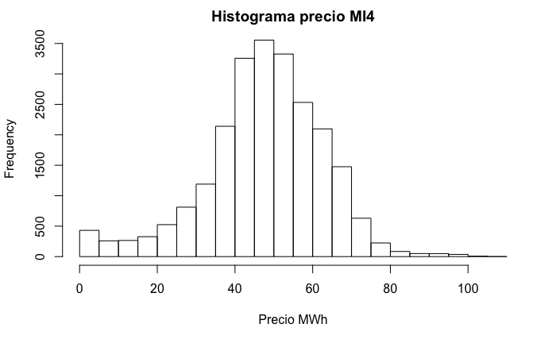

```r
#Creamos un histograma para observar la distribucion
hist_MI4<-hist(price_MI4, main="Histograma precio MI4", xlab="Precio MWh")
```

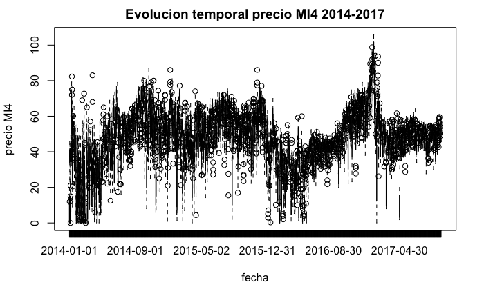

```r
#Analisis temporal evolucion precios
plot(electricity_prices$Date, electricity_prices$MI4, type="l", xlab="fecha", ylab="precio MI4", main="Evolucion temporal precio MI4 2014-2017")
```

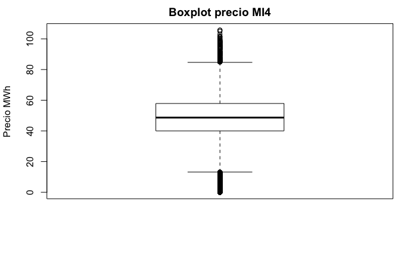

```r
#Creamos un boxplot
boxplot(price_MI4, main="Boxplot precio MI4", ylab= "Precio MWh")
```

```r
#Estudiamos los outliers mas extremos con precios elevados
outl_MI4<-prices_1[prices_1$MI4>90,]
out_MI4<-na.omit(outl_MI4)
out_MI4
```

|  | Date | Hour | DayofWeek | MD | MI1 | MI2 | MI3 | MI4 | MI5 | MI6 | MI7 | dem |
| --- | --- | --- | --- | --- | --- | --- | --- | --- | --- | --- | --- | --- |
| 26757 | 2017-01-19 | 22 | 4 | 89.19 | 91.17 | 93.00 | 91.50 | 92.00 | 92.00 | 92.00 | 99.80 | 40258 |
| 26781 | 2017-01-20 | 22 | 5 | 95.03 | 94.59 | 92.63 | 92.10 | 92.10 | 93.13 | 96.00 | 99.03 | 38861 |
| 26782 | 2017-01-20 | 23 | 5 | 94.70 | 95.86 | 94.70 | 93.67 | 94.78 | 94.70 | 95.80 | 99.70 | 36265 |
| 26783 | 2017-01-20 | 24 | 5 | 92.03 | 94.24 | 92.03 | 92.03 | 90.53 | 92.03 | 93.59 | 97.03 | 33366 |
| 26853 | 2017-01-23 | 22 | 1 | 90.76 | 96.51 | 97.69 | 94.76 | 95.00 | 95.19 | 96.13 | 90.76 | 38375 |
| 26854 | 2017-01-23 | 23 | 1 | 86.20 | 92.20 | 91.20 | 90.20 | 91.10 | 92.00 | 94.82 | 85.01 | 35487 |
| 26877 | 2017-01-24 | 22 | 2 | 96.30 | 96.40 | 96.40 | 96.98 | 96.80 | 96.40 | 99.00 | 97.99 | 38368 |
| 26878 | 2017-01-24 | 23 | 2 | 93.71 | 99.19 | 95.71 | 97.01 | 97.19 | 94.30 | 97.00 | 93.72 | 35427 |
| 26879 | 2017-01-24 | 24 | 2 | 90.74 | 98.51 | 97.01 | 95.74 | 95.74 | 93.74 | 98.74 | 92.20 | 31985 |
| 26901 | 2017-01-25 | 22 | 3 | 100.67 | 99.67 | 98.72 | 100.67 | 100.67 | 99.00 | 98.67 | 89.90 | 38312 |

[output cut: 2 more lines]

Como en los casos anteriores, los precios mas altos se producen en enero 2017 y la distribucion de la variable es asimetrica con mas frecuencia en precios bajos que altos.

# 1.5. Analisis de la variable precio MI_5

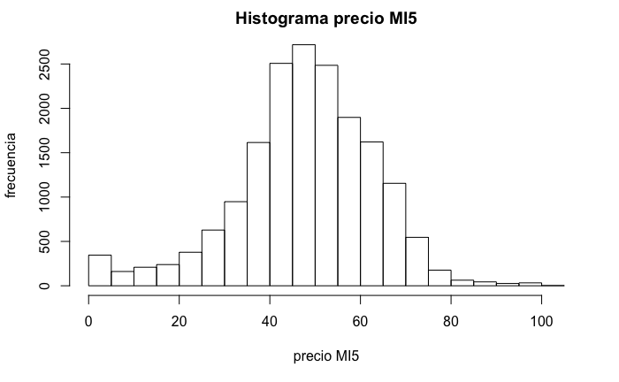

```r
#Creamos un histograma para observar la distribucion
hist_MI5<-hist(price_MI5, xlab="precio MI5", ylab="frecuencia",main="Histograma precio MI5")
```

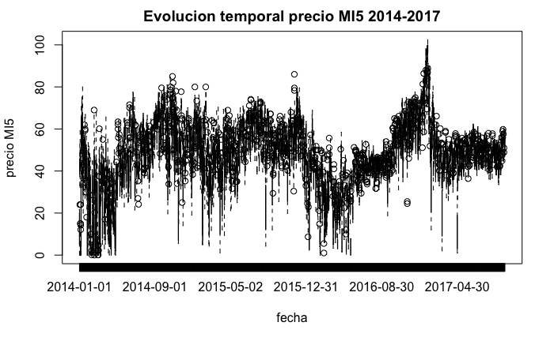

```r
#Analisis temporal evolucion precios
plot(electricity_prices$Date, electricity_prices$MI5, type="l", xlab="fecha", ylab="precio MI5", main="Evolucion temporal precio MI5 2014-2017")
```

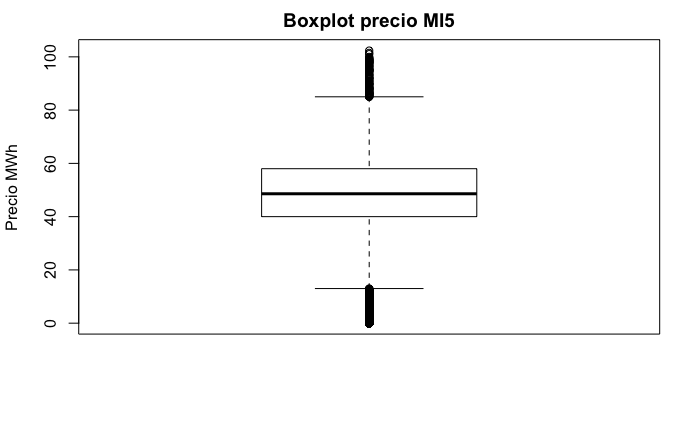

```r
#Creamos un boxplot
boxplot(price_MI5, main="Boxplot precio MI5", ylab= "Precio MWh")
```

```r
#Estudiamos los outliers mas extremos con precios elevados
outl_MI5<-prices_1[prices_1$MI5>90,]
out_MI5<-na.omit(outl_MI5)
out_MI5
```

|  | Date | Hour | DayofWeek | MD | MI1 | MI2 | MI3 | MI4 | MI5 | MI6 | MI7 | dem |
| --- | --- | --- | --- | --- | --- | --- | --- | --- | --- | --- | --- | --- |
| 26734 | 2017-01-18 | 23 | 3 | 89.22 | 89.25 | 89.25 | 90.72 | 89.22 | 90.01 | 93.51 | 95.00 | 37145 |
| 26757 | 2017-01-19 | 22 | 4 | 89.19 | 91.17 | 93.00 | 91.50 | 92.00 | 92.00 | 92.00 | 99.80 | 40258 |
| 26758 | 2017-01-19 | 23 | 4 | 85.46 | 88.46 | 90.10 | 92.46 | 89.50 | 92.77 | 90.46 | 98.19 | 37322 |
| 26781 | 2017-01-20 | 22 | 5 | 95.03 | 94.59 | 92.63 | 92.10 | 92.10 | 93.13 | 96.00 | 99.03 | 38861 |
| 26782 | 2017-01-20 | 23 | 5 | 94.70 | 95.86 | 94.70 | 93.67 | 94.78 | 94.70 | 95.80 | 99.70 | 36265 |
| 26783 | 2017-01-20 | 24 | 5 | 92.03 | 94.24 | 92.03 | 92.03 | 90.53 | 92.03 | 93.59 | 97.03 | 33366 |
| 26853 | 2017-01-23 | 22 | 1 | 90.76 | 96.51 | 97.69 | 94.76 | 95.00 | 95.19 | 96.13 | 90.76 | 38375 |
| 26854 | 2017-01-23 | 23 | 1 | 86.20 | 92.20 | 91.20 | 90.20 | 91.10 | 92.00 | 94.82 | 85.01 | 35487 |
| 26877 | 2017-01-24 | 22 | 2 | 96.30 | 96.40 | 96.40 | 96.98 | 96.80 | 96.40 | 99.00 | 97.99 | 38368 |
| 26878 | 2017-01-24 | 23 | 2 | 93.71 | 99.19 | 95.71 | 97.01 | 97.19 | 94.30 | 97.00 | 93.72 | 35427 |

[output cut: 4 more lines]

Los outliers con valores muy elevados se repiten en el mes de enero 2017.

# 1.6. Analisis de la variable precio MI_6

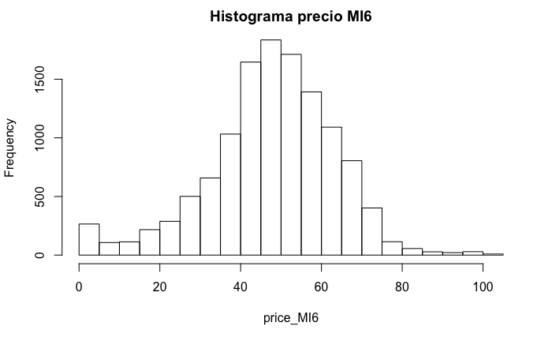

```r
#Creamos un histograma para observar la distribucion
hist_MI6<-hist(price_MI6, main="Histograma precio MI6")
```

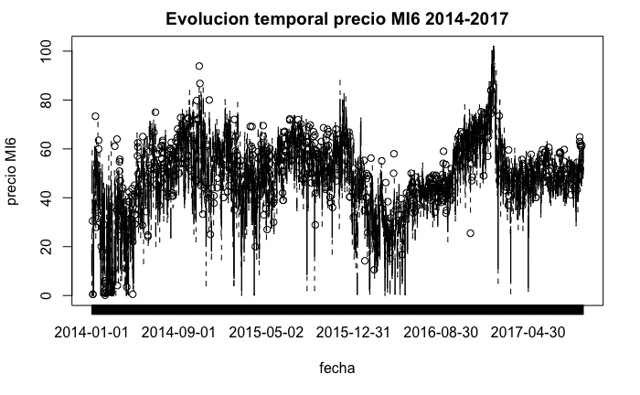

```r
#Analisis temporal evolucion precios
plot(electricity_prices$Date, electricity_prices$MI6, type="l", xlab="fecha", ylab="precio MI6", main="Evolucion temporal precio MI6 2014-2017")
```

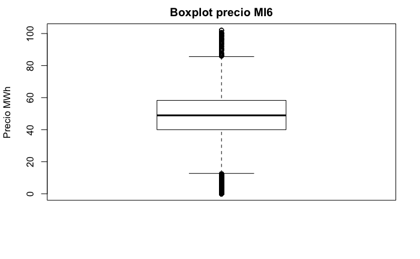

```r
#Creamos un boxplot
boxplot(price_MI6, main="Boxplot precio MI6", ylab= "Precio MWh")
```

```r
#Estudiamos los outliers mas extremos con precios elevados
outl_MI6<-prices_1[prices_1$MI6>90,]
out_MI6<-na.omit(outl_MI6)
out_MI6
```

|  | Date | Hour | DayofWeek | MD | MI1 | MI2 | MI3 | MI4 | MI5 | MI6 | MI7 | dem |
| --- | --- | --- | --- | --- | --- | --- | --- | --- | --- | --- | --- | --- |
| 26733 | 2017-01-18 | 22 | 3 | 92.01 | 90.29 | 90.29 | 91.41 | 89.01 | 89.79 | 93.01 | 97.00 | 40358 |
| 26734 | 2017-01-18 | 23 | 3 | 89.22 | 89.25 | 89.25 | 90.72 | 89.22 | 90.01 | 93.51 | 95.00 | 37145 |
| 26757 | 2017-01-19 | 22 | 4 | 89.19 | 91.17 | 93.00 | 91.50 | 92.00 | 92.00 | 92.00 | 99.80 | 40258 |
| 26758 | 2017-01-19 | 23 | 4 | 85.46 | 88.46 | 90.10 | 92.46 | 89.50 | 92.77 | 90.46 | 98.19 | 37322 |
| 26781 | 2017-01-20 | 22 | 5 | 95.03 | 94.59 | 92.63 | 92.10 | 92.10 | 93.13 | 96.00 | 99.03 | 38861 |
| 26782 | 2017-01-20 | 23 | 5 | 94.70 | 95.86 | 94.70 | 93.67 | 94.78 | 94.70 | 95.80 | 99.70 | 36265 |
| 26783 | 2017-01-20 | 24 | 5 | 92.03 | 94.24 | 92.03 | 92.03 | 90.53 | 92.03 | 93.59 | 97.03 | 33366 |
| 26853 | 2017-01-23 | 22 | 1 | 90.76 | 96.51 | 97.69 | 94.76 | 95.00 | 95.19 | 96.13 | 90.76 | 38375 |
| 26854 | 2017-01-23 | 23 | 1 | 86.20 | 92.20 | 91.20 | 90.20 | 91.10 | 92.00 | 94.82 | 85.01 | 35487 |
| 26855 | 2017-01-23 | 24 | 1 | 85.50 | 89.48 | 85.50 | 87.50 | 85.50 | 87.50 | 90.50 | 85.50 | 31968 |

[output cut: 7 more lines]

De nuevo, los outliers con valores elevados mas extremos se repiten en enero 2017.

# 1.7. An??alisis de la variable precio MI_7

[figure not shown]

```r
#Creamos un histograma para observar la distribucion
hist_MI7<-hist(price_MI2, main="Histograma precio MI7")
```

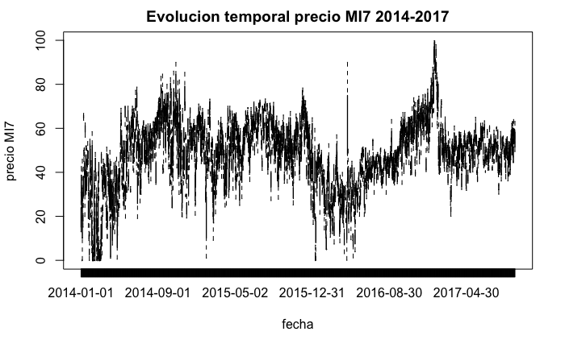

```r
#Analisis temporal evolucion precios
plot(electricity_prices$Date, electricity_prices$MI7, type="l", xlab="fecha", ylab="precio MI7", main="Evolucion temporal precio MI7 2014-2017")
```

# 1.8. Analisis distribucion conjunto de precios

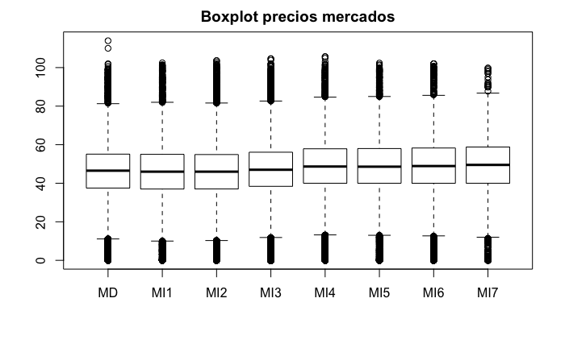

```r
#Creamos un boxplot de todos los precios para comparar visualmente sus distribuciones
boxplot(prices, main="Boxplot precios mercados")
```

Comparamos con un boxplot todas las distribuciones y observamos que son muy similares (la media de precios es muy similar, asi como los cuartiles y los valores extremos).

# 2. Correlaciones entre precios

```r
cor(prices, use="complete")
```

```
           MD       MI1       MI2       MI3       MI4       MI5       MI6       MI7
MD  1.0000000 0.9783742 0.9686569 0.9518946 0.9395039 0.9415883 0.9169176 0.8750996
MI1 0.9783742 1.0000000 0.9869271 0.9717384 0.9618042 0.9630435 0.9388087 0.8984333
MI2 0.9686569 0.9869271 1.0000000 0.9839501 0.9736182 0.9714335 0.9455367 0.9100365
MI3 0.9518946 0.9717384 0.9839501 1.0000000 0.9815205 0.9739185 0.9474180 0.9146195
MI4 0.9395039 0.9618042 0.9736182 0.9815205 1.0000000 0.9783639 0.9512885 0.9158251
MI5 0.9415883 0.9630435 0.9714335 0.9739185 0.9783639 1.0000000 0.9615410 0.9237293
MI6 0.9169176 0.9388087 0.9455367 0.9474180 0.9512885 0.9615410 1.0000000 0.9401105
MI7 0.8750996 0.8984333 0.9100365 0.9146195 0.9158251 0.9237293 0.9401105 1.0000000
```

Observamos que existe una relacion muy fuerte entre el precio de los diferentes mercados. El coeficiente de correlacion entre los diferentes precios tiene valores cercanos al 1. La relacion es positiva, por lo tanto, los precios se mueven cojuntamente en la misma direccion y no a la inversa.

# 1.9. Analisis del precio medio de todos los mercados

```r
#Creamos una variable que recoja el precio medio de la electricidad con el promedio de los diferentes mercados y la nombramos PM
electricity_prices$PM<-rowMeans(prices, na.rm=TRUE)
electricity_prices$PM<-round(electricity_prices$PM, digits=2)
PM<-electricity_prices$PM #Creamos un vector con los precios medios de electricidad
```

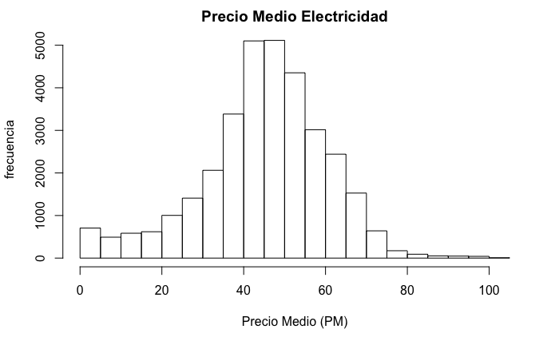

```r
#Creamos un histograma para observar la distribucion
hist(PM, xlab="Precio Medio (PM)", ylab="frecuencia", main="Precio Medio Electricidad")
```

La distribucion, como en la de los mercados individuales presenta una ligera asimetria y mas frecuencia en precios bajos.

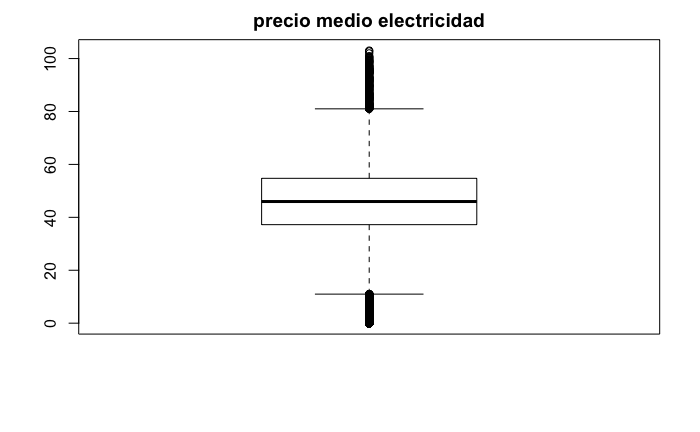

```r
#Creamos boxplot para observar los valores mas relevantes
boxplot(PM, main = "precio medio electricidad")
```

```r
#Observamos la descripcion estadistica de la variable
summary(PM)
```

```
   Min. 1st Qu.  Median    Mean 3rd Qu.    Max.
   0.00   37.23   45.97   44.93   54.74  103.00
```

La gran parte de precios oscilan entre 37.23 y 54.74 euros, con una media de 44.93.

```r
#Detectamos valores extremos
out_price<-boxplot.stats(PM)$out
head(out_price)
```

```
[1] 5.15 1.37 1.25 0.50 0.98 0.00
```

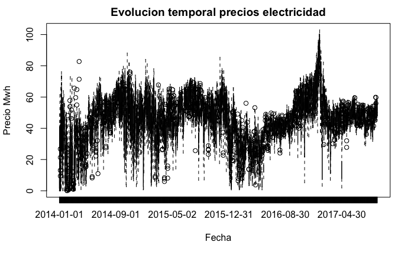

```r
#Observamos la evolucion de la variable a lo largo del tiempo
plot(electricity_prices$Date, electricity_prices$PM, main="Evolucion temporal precios electricidad", xlab="Fecha", ylab= "Precio Mwh")
```

# 2. Analisis de la variable demanda

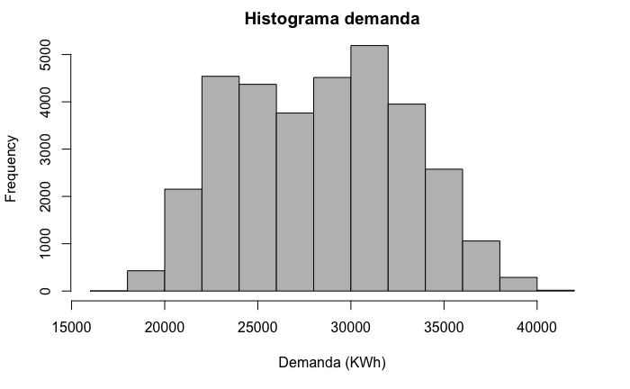

```r
#Creamos un histograma para observar la demanda
hist_dm<-hist(ep$dem, main="Histograma demanda", xlab= "Demanda (KWh)", col="grey")
```

```r
#Miramos la normalidad
skewness(ep$dem)
```

```
[1] 0.05939251
```

```r
kurtosis(ep$dem)
```

```
[1] -0.8983007
```

```r
z_kurtosis<-kurtosis(ep$dem)/sqrt(24/32855)
z_kurtosis
```

```
[1] -33.23662
```

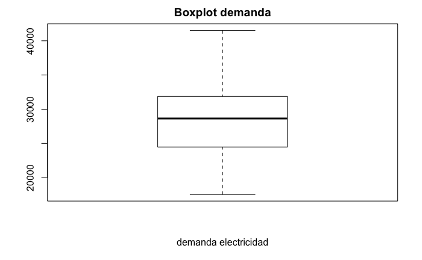

```r
#Creamos un boxplot de la demanda
boxplot_dem<-boxplot(electricity_prices$dem, xlab="demanda electricidad", main="Boxplot demanda")
```

```r
boxplot_dem
```

```
$stats
        [,1]
[1,] 17534.0
[2,] 24477.0
[3,] 28641.0
[4,] 31865.5
[5,] 41514.0

$n
[1] 32855

$conf
        [,1]
[1,] 28576.6
[2,] 28705.4

$out
numeric(0)

$group
numeric(0)

$names
[1] ""
```

No se observan distribuciones muy extremas (outliers).

```r
#Observamos la descripcion estadistica de la variable
summary(ep$dem)
```

```
   Min. 1st Qu.  Median    Mean 3rd Qu.    Max.
  17530   24480   28640   28380   31870   41510
```

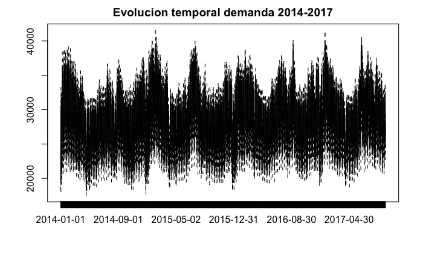

```r
#Creamos un histograma para observar la evolucion de la demanda
plot(electricity_prices$Date, electricity_prices$dem, main="Evolucion temporal demanda 2014-2017")
```

La evolucion de la demanda es claramente ciclica.